# fazorsa_OriginalHomeworkCode_04

Frank Azorsa

10/24/2019

### First question:

Write a simple R function, Z.prop.test(), that can perform one- or two-sample Z-tests for proportion data, using the following guidelines: Your function should take the following arguments: p1 and n1 (no default) representing the estimated proportion and sample size (i.e., based on your sample data); p2 and n2 (both defaulting to NULL) that contain a second sample’s proportion and sample size data in the event of a two-sample test; p0 (no default) as the expected value for the population proportion; and alternative (default “two.sided”) and conf.level (default 0.95), to be used in the same way as in the function t.test(). When conducting a two-sample test, it should be p1 that is tested as being smaller or larger than p2 when alternative=“less” or alternative=“greater”, the same as in the use of x and y in the function t.test(). The function should perform a one-sample Z-test using p1, n1, and p0 if either p2 or n2 (or both) is NULL. The function should contain a check for the rules of thumb we have talked about (n∗p>5 and n∗(1−p)>5) to ensure the validity of assuming the normal distribution in both the one- and two-sample settings. If this is violated, the function should still complete but it should also print an appropriate warning message. The function should return a list containing the members Z (the test statistic), P (the appropriate p value), and CI (the two-sided CI with respect to “conf.level” around p1 in the case of a one-sample test and around p2-p1 in the case of a two-sample test). For all test alternatives (“two.sided”, “greater”, “less”), calculate symmetric CIs based on quantiles of the normal distribution rather than worrying about calculating single-limit confidence bounds. ***

```r
z.prop.test <- function(p1, n1, p0, p2=NULL, n2=NULL, alternative="two.sided", conf.level=0.95) {
   z <- NULL
   ci <- NULL
   p.val <- NULL
      phat <- p1/n1 #Sample proportion

         if(alternative=="two.sided") {
        SE.phat <- sqrt(phat*(1-phat)/n1)# standar error of the sample proportion
         z <- (phat - p1)/SE.phat
         p.val <- pnorm(z, lower.tail = FALSE)# p-value for upper tail z-test
         lower <- phat - qnorm(conf.level)*SEphat
         upper <- phat + qnorm(conf.level)*SEphat
         ci <- c(lower, upper)         }

          if(alternative=="less") {
        SE.phat <- sqrt(phat*(1-phat)/n1)# standar error of the sample proportion
         z <- (phat - p1)/SE.phat
         p.val <- pnorm(z, lower.tail = FALSE)# p-value for upper tail z-test
         lower <- phat - qnorm(conf.level)*SEphat
         upper <- phat + qnorm(conf.level)*SEphat
         ci <- c(lower, upper)         }

         if(alternative=="greater") {
        SE.phat <- sqrt(phat*(1-phat)/n1)# standar error of the sample proportion
         z <- (phat - p1)/SE.phat
         p.val <- pnorm(z, lower.tail = FALSE)# p-value for upper tail z-test
         lower <- phat - qnorm(conf.level)*SEphat
         upper <- phat + qnorm(conf.level)*SEphat
         ci <- c(lower, upper)         }

         if(is.null(n2)|is.null(p2)) {
         SE.phat <- sqrt(phat*(1-phat)/n1)# standar error of the sample proportion
         z <- (phat - p1)/SE.phat
         p.val <- pnorm(z, lower.tail = FALSE)# p-value for upper tail z-test
         lower <- phat - qnorm(conf.level)*SEphat
         upper <- phat + qnorm(conf.level)*SEphat
         ci <- c(lower, upper)
         }
}
      #else {
         #SE.phat <- sqrt(phat*(1-phat)/n1)
      #}
      #ci <- phat + c(
         #-1*((qnorm(((1 - conf.level)/2) + conf.level))*SE.phat),
         #((qnorm(((1 - conf.level)/2) + conf.level))*SE.phat))

      #return(list(estimate=phat, z=z, p.val=p.val, ci=ci))
      #}
#values <- c(z, p.val, ci)
#print(values)
```

### Challenges first question: I am still working on this function, and I am still getting errors and I am not sure if this is the correct way to present it - I will keep working.

### Second question:

The dataset from Kamilar and Cooper has in it a large number of variables related to life history and body size. For this exercise, the end aim is to fit a simple linear regression model to predict longevity (MaxLongevity_m) measured in months from species’ brain size (Brain_Size_Species_Mean) measured in grams. Do the following for both longevity~brain size and log(longevity)~log(brain size): ***

```r
#Loading the dataset “KamilarAndCooperData.csv” and the ggplot library
library(ggplot2)
library(curl)
f <- curl("https://raw.githubusercontent.com/fuzzyatelin/fuzzyatelin.github.io/master/AN597_Fall19/KamilarAndCooperData.csv")
d <- read.csv(f, header = TRUE, sep = ",", stringsAsFactors = FALSE)
head(d)
```

```
##               Scientific_Name          Family          Genus      Species
## 1 Allenopithecus_nigroviridis Cercopithecidae Allenopithecus nigroviridis
## 2         Allocebus_trichotis Cercopithecidae      Allocebus    trichotis
## 3           Alouatta_belzebul        Atelidae       Alouatta     belzebul
## 4             Alouatta_caraya        Atelidae       Alouatta       caraya
## 5            Alouatta_guariba        Atelidae       Alouatta      guariba
## 6           Alouatta_palliata        Atelidae       Alouatta     palliata
##   Brain_Size_Species_Mean Brain_Size_Female_Mean   Brain_size_Ref
## 1                   58.02                  53.70 Isler et al 2008
## 2                      NA                     NA
## 3                   52.84                  51.19 Isler et al 2008
## 4                   52.63                  47.80 Isler et al 2008
## 5                   51.70                  49.08 Isler et al 2008
## 6                   49.88                  48.04 Isler et al 2008
##   Body_mass_male_mean Body_mass_female_mean Mass_Dimorphism
```

[output cut: 69 more lines]

Fit the regression model and, using {ggplot2}, produce a scatterplot with the fitted line superimposed upon the data. Append the the fitted model equation to your plot (HINT: use the function geom_text()).

```r
lm_fit <- lm(MaxLongevity_m ~ Brain_Size_Species_Mean, data = d)
summary(lm_fit)
```

```
##
## Call:
## lm(formula = MaxLongevity_m ~ Brain_Size_Species_Mean, data = d)
##
## Residuals:
##     Min      1Q  Median      3Q     Max
## -198.27  -61.92  -17.78   56.16  331.36
##
## Coefficients:
##                         Estimate Std. Error t value Pr(>|t|)
## (Intercept)             248.9523    11.1111   22.41   <2e-16 ***
## Brain_Size_Species_Mean   1.2180     0.1101   11.06   <2e-16 ***
## ---
## Signif. codes:  0 '***' 0.001 '**' 0.01 '*' 0.05 '.' 0.1 ' ' 1
##
## Residual standard error: 90.91 on 126 degrees of freedom
##   (85 observations deleted due to missingness)
## Multiple R-squared:  0.4928, Adjusted R-squared:  0.4887
## F-statistic: 122.4 on 1 and 126 DF,  p-value: < 2.2e-16
```

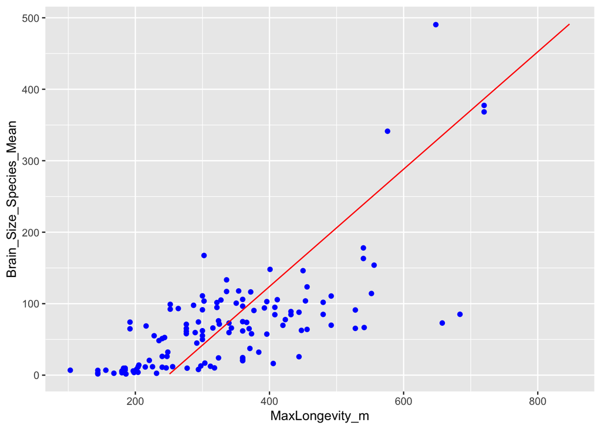

```r
predicted_d <- data.frame(MaxLongevity_m_pred = predict(lm_fit, d), Brain_Size_Species_Mean=d$Brain_Size_Species_Mean)
ggplot(data = d, aes(x = MaxLongevity_m, y = Brain_Size_Species_Mean)) +
  geom_point(color='blue') +
  geom_line(color='red',data = predicted_d, aes(x=MaxLongevity_m_pred, y=Brain_Size_Species_Mean))
```

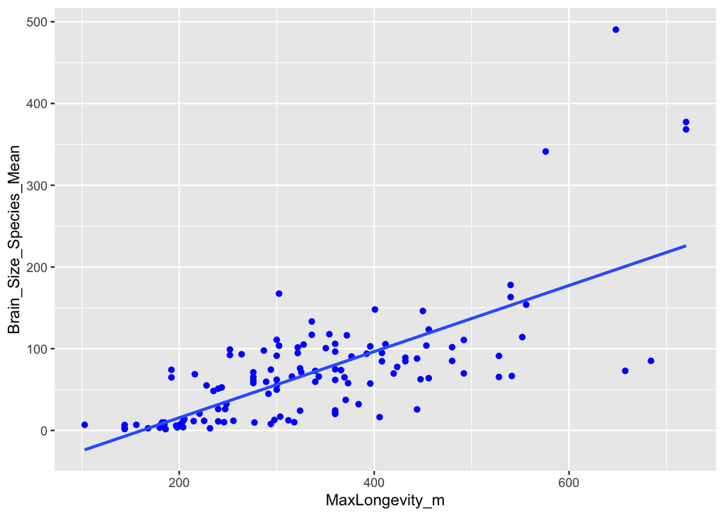

```r
ggplot(data = d, aes(x = MaxLongevity_m, y = Brain_Size_Species_Mean)) +
  geom_point(color='blue') +
  geom_smooth(method = "lm", se = FALSE)
```

Identify and interpret the point estimate of the slope (β1), as well as the outcome of the test associated with the hypotheses H0: β1 = 0; HA: β1 ≠ 0. Also, find a 90 percent CI for the slope (β1) parameter.

```r
lm_fit
```

```
##
## Call:
## lm(formula = MaxLongevity_m ~ Brain_Size_Species_Mean, data = d)
##
## Coefficients:
##             (Intercept)  Brain_Size_Species_Mean
##                 248.952                    1.218
```

```r
t <- coef(summary(lm_fit))
t <- data.frame(unlist(t))
colnames(t) <- c("Est", "SE", "t", "p")
t
```

```
##                               Est         SE       t            p
## (Intercept)             248.95227 11.1111143 22.4057 8.910319e-46
## Brain_Size_Species_Mean   1.21799  0.1100879 11.0638 2.685909e-20
```

```r
ci <- confint(lm_fit, level = 0.90)
ci
```

```
##                                5 %      95 %
## (Intercept)             230.540738 267.36379
## Brain_Size_Species_Mean   1.035571   1.40041
```

Using your model, add lines for the 90 percent confidence and prediction interval bands on the plot and add a legend to differentiate between the lines.

```r
ci <- predict(lm_fit, newdata = data.frame(Brain_Size_Species_Mean=d$Brain_Size_Species_Mean), interval = "confidence",
    level = 0.90)
h_hat <- predict(lm_fit, newdata = data.frame(Brain_Size_Species_Mean=d$Brain_Size_Species_Mean))
df <- data.frame(cbind(d$Brain_Size_Species_Mean, d$MaxLongevity_m, h_hat))
names(df) <- c("x", "y", "yhat")
df <- cbind(df, ci)
names(df) <- c("x", "y", "yhat", "CIfit", "CIlwr", "CIupr")
head(df)
```

```
##       x     y     yhat    CIfit    CIlwr    CIupr
## 1 58.02 276.0 319.6201 319.6201 306.1354 333.1047
## 2    NA    NA       NA       NA       NA       NA
## 3 52.84    NA 313.3109 313.3109 299.6449 326.9768
## 4 52.63 243.6 313.0551 313.0551 299.3805 326.7297
## 5 51.70    NA 311.9224 311.9224 298.2081 325.6366
## 6 49.88 300.0 309.7056 309.7056 295.9081 323.5032
```

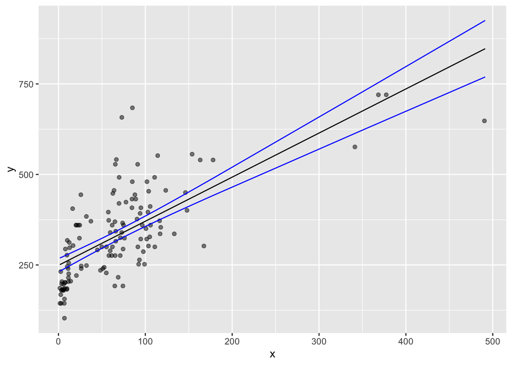

```r
g <- ggplot(data = df, aes(x = x, y = y))
g <- g + geom_point(alpha = 1/2)
g <- g + geom_line(aes(x = x, y = CIfit), colour = "black")
g <- g + geom_line(aes(x = x, y = CIlwr), colour = "blue")
g <- g + geom_line(aes(x = x, y = CIupr), colour = "blue")
g
```

Produce a point estimate and associated 90 percent PI for the longevity of a species whose brain weight is 800 gm. Do you trust the model to predict observations accurately for this value of the explanatory variable? Why or why not?

```r
ci <- predict(lm_fit, newdata = data.frame(Brain_Size_Species_Mean=800), interval = "confidence",
      level = 0.90)
ci
```

```
##        fit      lwr      upr
## 1 1223.345 1089.461 1357.228
```

Looking at your two models, which do you think is better? Why?

### Challenges second question: I still need to finish the last part of this question and test again each part of the code.